# VLAD.FOSTER

CHI SQUARE

creating a subset for chi square

```r
foster.chi.variables <- c("ctkfamst", "race")
foster.chi <- foster[foster.chi.variables]
```

table for observed count

```r
tbl2 <- table(foster.chi$race, foster.chi$ctkfamst)
tbl2
```

```
                            Married couple Single female Single male
  White                              64280        132517       19405
  American Indian                     1560          6629         736
  Asian                                896          1081         172
  Pacific Islander                     355           681          84
  Multiple Race                       7107         23195        2548
  Black or African American          11951         75397        5701

                            Unmarried couple
  White                                83634
  American Indian                       3212
  Asian                                  610
  Pacific Islander                       570
  Multiple Race                        11890
  Black or African American            24206
```

```r
proportions(tbl2, 1)
```

```
                            Married couple Single female Single male
  White                         0.21438386    0.44196494  0.06471871
  American Indian               0.12853259    0.54618110  0.06064102
  Asian                         0.32475535    0.39180863  0.06234143
  Pacific Islander              0.21005917    0.40295858  0.04970414
  Multiple Race                 0.15885114    0.51843987  0.05695127
  Black or African American     0.10192316    0.64301736  0.04862053

                            Unmarried couple
  White                           0.27893248
  American Indian                 0.26464530
  Asian                           0.22109460
  Pacific Islander                0.33727811
  Multiple Race                   0.26575771
  Black or African American       0.20643896
```

table for observed count

```r
tbl3 <- table(foster.chi$ctkfamst, foster.chi$race)
tbl3
```

```
                    White American Indian  Asian Pacific Islander Multiple Race
  Married couple    64280            1560    896              355          7107
  Single female    132517            6629   1081              681         23195
  Single male       19405             736    172               84          2548
  Unmarried couple  83634            3212    610              570         11890

                   Black or African American
  Married couple                       11951
  Single female                        75397
  Single male                           5701
  Unmarried couple                     24206
```

observed proportion

```r
proportions(tbl2,1)
```

```
                            Married couple Single female Single male
  White                         0.21438386    0.44196494  0.06471871
  American Indian               0.12853259    0.54618110  0.06064102
  Asian                         0.32475535    0.39180863  0.06234143
  Pacific Islander              0.21005917    0.40295858  0.04970414
  Multiple Race                 0.15885114    0.51843987  0.05695127
  Black or African American     0.10192316    0.64301736  0.04862053

                            Unmarried couple
  White                           0.27893248
  American Indian                 0.26464530
  Asian                           0.22109460
  Pacific Islander                0.33727811
  Multiple Race                   0.26575771
  Black or African American       0.20643896
```

chi square independence test + correlation plot

```r
chisq2 <- chisq.test(x=tbl2, correct=FALSE)
colors6<-c("#664799" , "#895FCC", "#A976FC", "#0DDBB2","#0AAD8C", "#07846B")
colors2<- c("#083D87", "#F21D25")
names(chisq2)
```

```
[1] "statistic" "parameter" "p.value"   "method"    "data.name" "observed"
[7] "expected"  "residuals" "stdres"
```

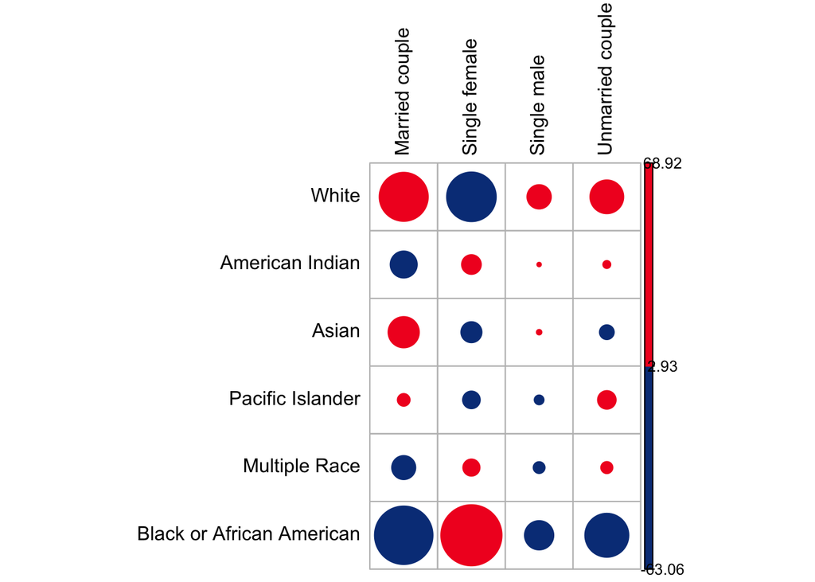

```r
corrplot(chisq2$residuals, is.cor = FALSE, col=colors2, tl.col="black")
```

SIMPLE LINEAR REGRESSION

cleaning up age

```r
foster = foster[!foster$ageatstart == "DOB Missing",]
foster$ageatstart <- as.numeric(foster$ageatstart)
foster = foster[!foster$ageatstart <=0,]
```

creating a subset

```r
foster.slr.variables <- c("ctkfamst", "race", "lifelos", "ageatstart", "sex")
foster.slr <- foster[foster.slr.variables]
sum_up(foster.slr, ageatstart)
```

```
  Variable │      Obs  Missing     Mean   StdDev      Min      Max
───────────┼───────────────────────────────────────────────────────
ageatstart │   420158        0  8.47315  5.29597        1       28
```

cleaning up gender

```r
foster.slr <- foster.slr %>%
  filter(foster.slr$sex %in% c("Female", "Male"))
tab(foster, sex)
```

```
   sex │    Freq.  Percent     Cum.
───────┼────────────────────────────
Female │   204473    48.67    48.67
  Male │   215685    51.33   100.00
```

cleaning up caretaker family structure

```r
foster.slr <- foster.slr%>%
  filter(foster.slr$ctkfamst %in% c("Married couple", "Unmarried couple", "Single female", "Single male"))
tab(foster.slr, ctkfamst)
```

```
        ctkfamst │    Freq.  Percent     Cum.
─────────────────┼────────────────────────────
  Married couple │    79904    19.02    19.02
   Single female │   209725    49.92    68.93
     Single male │    27853     6.63    75.56
Unmarried couple │   102676    24.44   100.00
```

cleaning up race variable

```r
foster.slr <- foster.slr%>%
  filter(foster.slr$race %in% c("White", "Black or African American", "American Indian or Alaska Native", "Asian", "Hawaiian or Other Pacific Islander", "More Than One Race"))
tab(foster.slr, race)
```

```
                     race │    Freq.  Percent     Cum.
──────────────────────────┼────────────────────────────
                    White │   261913    71.03    71.03
                    Asian │     2491     0.68    71.71
Black or African American │   104334    28.29   100.00
```

only keeping complete cases

```r
foster.slr <- foster.slr[complete.cases(foster.slr),]
```

slr model

```r
reg_model <- lm(lifelos ~ ageatstart, data=foster.slr)
summary(reg_model)
```

```
Call:
lm(formula = lifelos ~ ageatstart, data = foster.slr)

Residuals:
    Min      1Q  Median      3Q     Max
-1183.3  -456.3  -127.2   284.8  6460.7

Coefficients:
            Estimate Std. Error t value Pr(>|t|)
(Intercept) 473.2184     2.2152   213.6   <2e-16 ***
ageatstart   38.0056     0.2247   169.1   <2e-16 ***
---
Signif. codes:  0 '***' 0.001 '**' 0.01 '*' 0.05 '.' 0.1 ' ' 1

Residual standard error: 701.3 on 350149 degrees of freedom
Multiple R-squared:  0.07554,   Adjusted R-squared:  0.07554
F-statistic: 2.861e+04 on 1 and 350149 DF,  p-value: < 2.2e-16
```

confidence interval

```r
confint(reg_model, "ageatstart", level=0.95)
```

```
              2.5 %   97.5 %
ageatstart 37.56521 38.44597
```

check normality assumption

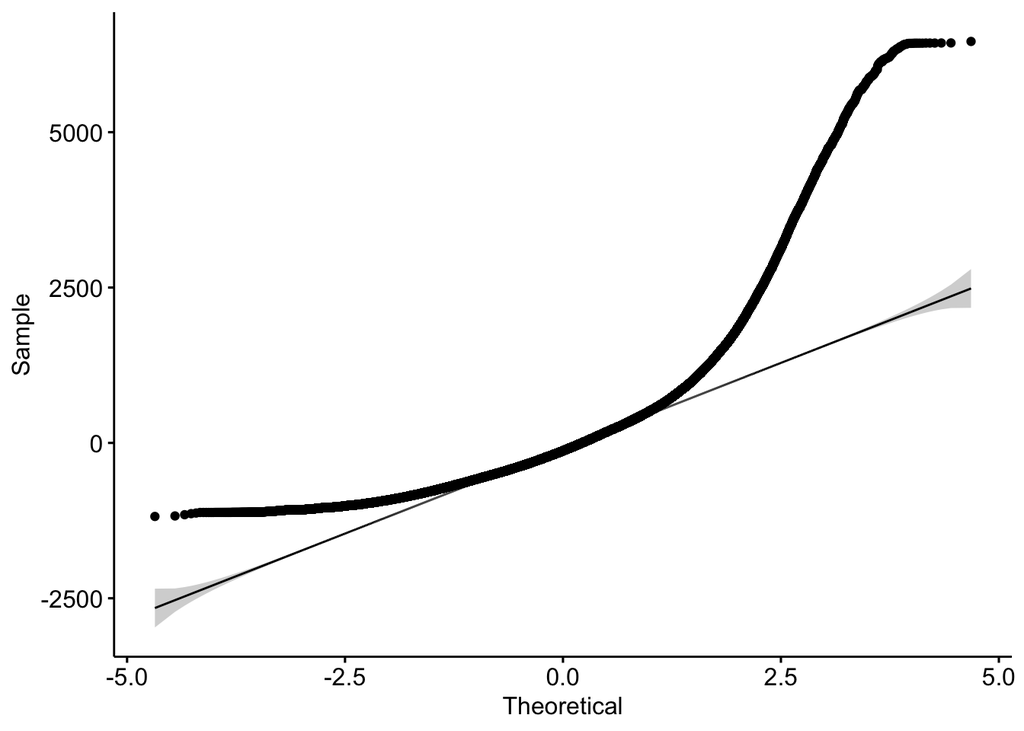

```r
reg_model$residuals %>%
  ggpubr::ggqqplot()
```

histogram of the residuals

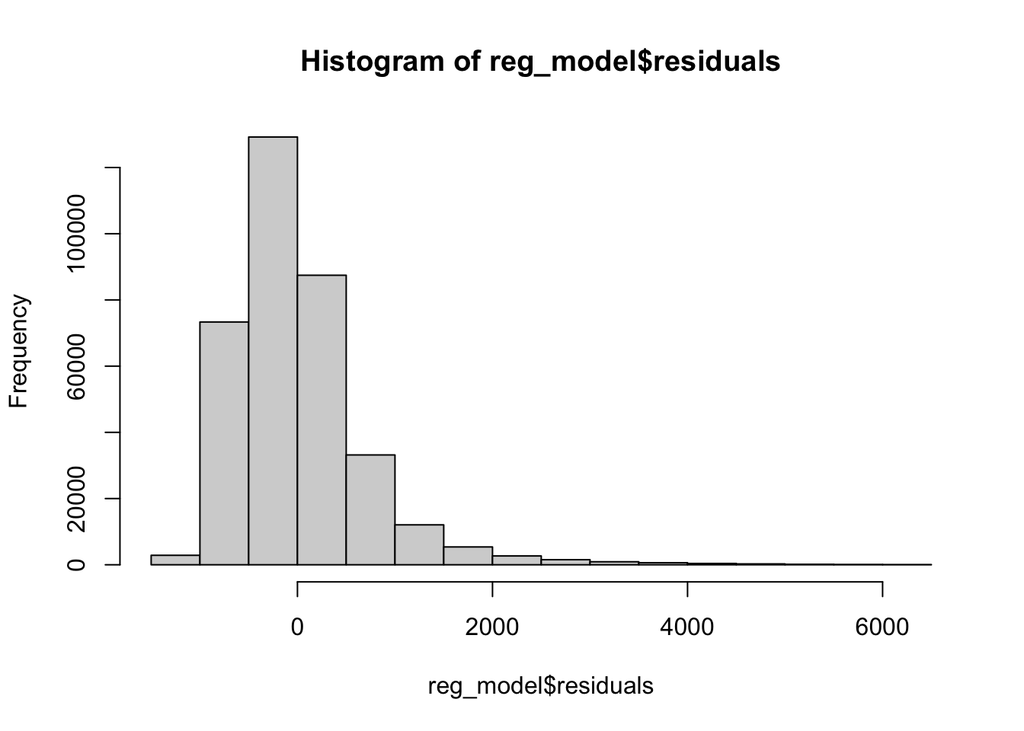

```r
hist(reg_model$residuals)
```

check constant variance

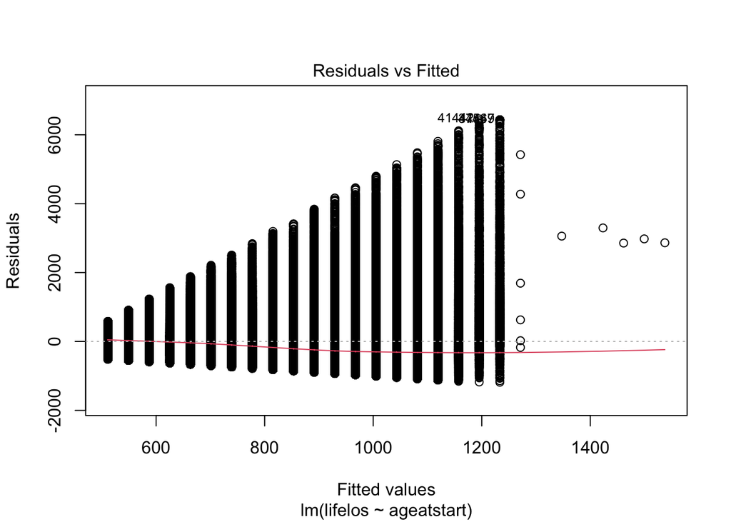

```r
plot(reg_model, 1)
```

multi layer scatterplot

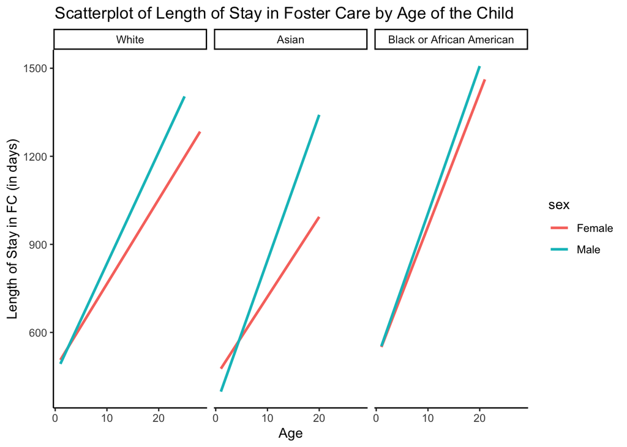

```r
foster.slr %>%
  dplyr::arrange(desc(ageatstart)) %>%
  ggplot(aes(as.numeric(ageatstart), as.numeric(lifelos))) +
  #geom_point(aes(size=.000001, color=sex), alpha=0.5) +
  geom_smooth(aes(color=sex), method='lm', se=F) +
  labs(x = "Age",
       y = "Length of Stay in FC (in days)",
       title = "Scatterplot of Length of Stay in Foster Care by Age of the Child") +
  theme_classic() +
  theme(plot.title=element_text(hjust=0.1)) + facet_wrap(~race)
```

```r
tab(foster.slr, race)
```

```
                     race │    Freq.  Percent     Cum.
──────────────────────────┼────────────────────────────
                    White │   249610    71.29    71.29
                    Asian │     2397     0.68    71.97
Black or African American │    98144    28.03   100.00
```

CHI SQUARE

creating a subset for chi square

```r
foster.chi1.variables <- c("ctkfamst", "disreasn")
foster.chi1 <- foster[foster.chi1.variables]
```

cleaning up disreasn variable

```r
foster.chi1 <- foster.chi1 %>%
  filter(foster.chi1$disreasn %in% c("Adoption", "Death of child", "Emancipation", "Guardianchip", "Living with other relative(s)", "Reunified with parent, primary caretaker", "Runaway"))
tab(foster.chi1, disreasn)
```

```
                                disreasn │    Freq.  Percent     Cum.
─────────────────────────────────────────┼────────────────────────────
                                Adoption │    44153    32.04    32.04
                          Death of child │      207     0.15    32.19
                            Emancipation │    15448    11.21    43.40
           Living with other relative(s) │     7404     5.37    48.77
Reunified with parent, primary caretaker │    70239    50.97    99.73
                                 Runaway │      367     0.27   100.00
```

changing names of categories for discharge reason to make space on poster

```r
foster.chi1$disreasn <-  recode_factor(foster.chi1$disreasn, "Reunified with parent, primary caretaker"= "Reunified with parent")
levels(foster.chi1$disreasn)
```

```
[1] "Reunified with parent"         "Emancipation"
[3] "Living with other relative(s)" "Runaway"
[5] "Adoption"                      "Death of child"
```

table for observed count

```r
tbl1 <- table(foster.chi1$disreasn, foster.chi1$ctkfamst)
tbl1
```

```
                                Married couple Single female Single male
  Reunified with parent                  14701         33922        4355
  Emancipation                            3955          7723        1691
  Living with other relative(s)           1473          4059         502
  Runaway                                   64           225          45
  Adoption                                7016         22583        2055
  Death of child                            34           108          13

                                Unmarried couple
  Reunified with parent                    17261
  Emancipation                              2079
  Living with other relative(s)             1370
  Runaway                                     33
  Adoption                                 12499
  Death of child                              52
```

table for observed count

```r
tbl <- table(foster.chi1$ctkfamst, foster.chi1$disreasn)
tbl
```

```
                   Reunified with parent Emancipation
  Married couple                   14701         3955
  Single female                    33922         7723
  Single male                       4355         1691
  Unmarried couple                 17261         2079

                   Living with other relative(s) Runaway Adoption
  Married couple                            1473      64     7016
  Single female                             4059     225    22583
  Single male                                502      45     2055
  Unmarried couple                          1370      33    12499

                   Death of child
  Married couple               34
  Single female               108
  Single male                  13
  Unmarried couple             52
```

observed proportion

```r
proportions(tbl,1)
```

```
                   Reunified with parent Emancipation
  Married couple            0.5396248578 0.1451749073
  Single female             0.4943456718 0.1125473623
  Single male               0.5028287727 0.1952430435
  Unmarried couple          0.5184417613 0.0624436835

                   Living with other relative(s)      Runaway     Adoption
  Married couple                    0.0540689351 0.0023492273 0.2575340454
  Single female                     0.0591518508 0.0032789274 0.3291023025
  Single male                       0.0579609745 0.0051957049 0.2372705230
  Unmarried couple                  0.0411485553 0.0009911696 0.3754129873

                   Death of child
  Married couple     0.0012480270
  Single female      0.0015738852
  Single male        0.0015009814
  Unmarried couple   0.0015618430
```

chi square independence test

```r
chisq <- chisq.test(x=tbl1, correct=FALSE)
```

view disreasn

```r
tab(foster, disreasn)
```

```
                                disreasn │    Freq.  Percent     Cum.
─────────────────────────────────────────┼────────────────────────────
                                Adoption │    44153    10.51    10.51
                          Death of child │      207     0.05    10.56
                            Emancipation │    15448     3.68    14.23
                            Guardianship │    18000     4.28    18.52
           Living with other relative(s) │     7404     1.76    20.28
                                 Missing │   262943    62.58    82.86
Reunified with parent, primary caretaker │    70239    16.72    99.58
                                 Runaway │      367     0.09    99.67
              Transfer to another agency │     1397     0.33   100.00
```

correlation plot

```r
#tl.srt tilts the labels at a 45 degree angle
#tl.col specifies the color of the factor labels on the contingency table
colors6<-c("#664799" , "#895FCC", "#A976FC", "#0DDBB2","#0AAD8C", "#07846B")
colors2<- c("#083D87", "#F21D25")
names(chisq)
```

```
[1] "statistic" "parameter" "p.value"   "method"    "data.name" "observed"
[7] "expected"  "residuals" "stdres"
```

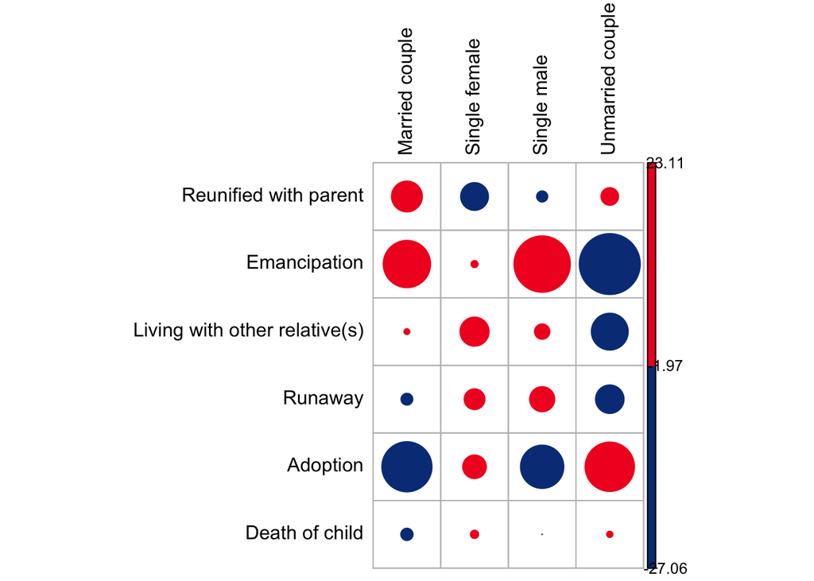

```r
corrplot(chisq$residuals, is.cor = FALSE, col=colors2, tl.col="black")
```

```r
#corrplot(chisq$stdres, is.cor = FALSE, col=colors2, tl.col="black", tl.srt=45)
#corrplot::corrplot(chisq$residuals, is.cor = FALSE, col=colors2, tl.col="black", tl.srt=45)
```

ONE WAY ANOVA

creating a subset for one way anova

```r
foster.one.way.variables <- c("lifelos", "race")
foster.one.way <- foster[foster.one.way.variables]
```

cleaning up race variable

```r
foster.one.way <- foster.one.way%>%
  filter(foster.one.way$race %in% c("White", "Black or African American", "American Indian or Alaska Native", "Asian", "Hawaiian or Other Pacific Islander", "More Than One Race"))
tab(foster.one.way, race)
```

```
                     race │    Freq.  Percent     Cum.
──────────────────────────┼────────────────────────────
                    White │   261913    71.03    71.03
                    Asian │     2491     0.68    71.71
Black or African American │   104334    28.29   100.00
```

cleaning up lifelos

```r
foster.one.way = foster.one.way[!foster.one.way$lifelos <=0,]
sum_up(foster.one.way, lifelos)
```

```
Variable │      Obs  Missing     Mean   StdDev      Min      Max
─────────┼───────────────────────────────────────────────────────
 lifelos │   349872    18587  790.405   729.33        1     7670
```

HOMOGENEITY OF VARIANCES rotate (rename to make shorter)

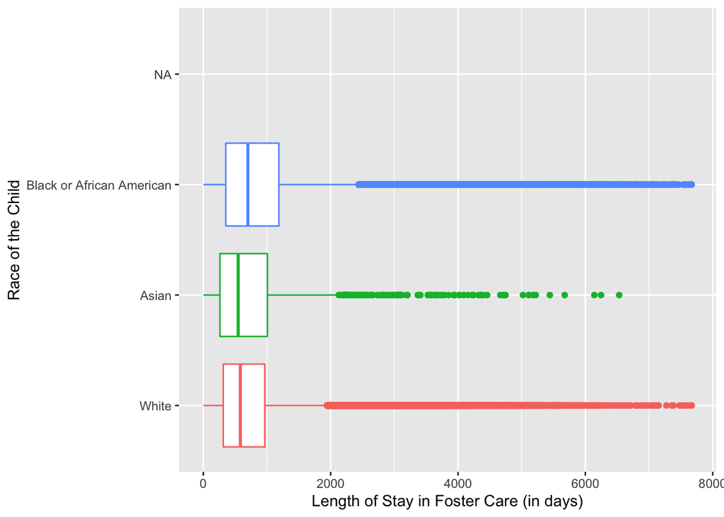

```r
plot <- ggplot(foster.one.way, aes(x=lifelos, y = race, color = race)) +
  labs(y = "Race of the Child", x = "Length of Stay in Foster Care (in days)") +
  geom_boxplot()+theme(legend.position = "none")
plot
```

ONE WAY ANOVA

```r
one.way1 <- aov(lifelos ~ race, data = foster.one.way)
summary(one.way1)
```

```
                Df    Sum Sq   Mean Sq F value Pr(>F)
race             2 2.094e+09 1.047e+09    1990 <2e-16 ***
Residuals   349869 1.840e+11 5.259e+05
---
Signif. codes:  0 '***' 0.001 '**' 0.01 '*' 0.05 '.' 0.1 ' ' 1
18587 observations deleted due to missingness
```

summary statistics

```r
by(foster.one.way$lifelos, foster.one.way$race, summary)
```

```
foster.one.way$race: White
   Min. 1st Qu.  Median    Mean 3rd Qu.    Max.
    1.0   314.0   582.0   741.9   966.0  7670.0
------------------------------------------------------------
foster.one.way$race: American Indian
NULL
------------------------------------------------------------
foster.one.way$race: Asian
   Min. 1st Qu.  Median    Mean 3rd Qu.    Max.
    1.0   261.0   548.0   762.3  1007.0  6531.0
------------------------------------------------------------
foster.one.way$race: Pacific Islander
NULL
------------------------------------------------------------
foster.one.way$race: Multiple Race
NULL
------------------------------------------------------------
foster.one.way$race: Black or African American
   Min. 1st Qu.  Median    Mean 3rd Qu.    Max.
    1.0   353.0   700.0   914.3  1187.0  7669.0
```

```r
tab(foster.one.way, race)
```

```
                     race │    Freq.  Percent     Cum.
──────────────────────────┼────────────────────────────
                    White │   249399    67.69    67.69
                    Asian │     2397     0.65    68.34
Black or African American │    98076    26.62    94.96
                       NA │    18587     5.04   100.00
```

post-hoc test

```r
TukeyHSD(one.way1, conf.level = 0.95)
```

```
  Tukey multiple comparisons of means
    95% family-wise confidence level

Fit: aov(formula = lifelos ~ race, data = foster.one.way)

$race
                                     diff       lwr      upr     p adj
Asian-White                      20.40178 -14.48124  55.2848 0.3563306
Black or African American-White 172.37630 165.97005 178.7826 0.0000000
Black or African American-Asian 151.97452 116.83625 187.1128 0.0000000
```

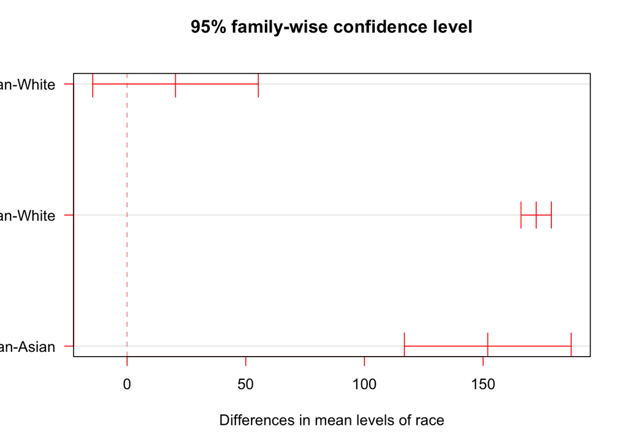

```r
plot(TukeyHSD(one.way1, conf.level = 0.95), las=1, col = "red")
```

```r
tukey.plot.aov <- aov(lifelos ~ race, data=foster.one.way)
```

mean, sd

```r
group_by(foster.one.way, race) %>%
  summarise(
    count = n(),
    mean = mean(lifelos, na.rm = TRUE),
    sd = sd(lifelos, na.rm = TRUE),
    median = median(lifelos, na.rm = TRUE),
    min = min(lifelos, na.rm = TRUE),
    max = max(lifelos, na.rm = TRUE)
  )
```

```
# A tibble: 4 × 7
  race                       count  mean    sd median   min   max
  <fct>                      <int> <dbl> <dbl>  <dbl> <dbl> <dbl>
1 White                     249399  742.  664.    582     1  7670
2 Asian                       2397  762.  776.    548     1  6531
3 Black or African American  98076  914.  861.    700     1  7669
4 <NA>                       18587  NaN    NA      NA   Inf  -Inf
```

#fs <- oneway.test(lifelos ~ race, data=foster.one.way) #fs #foster.one.way%>% welch_anova_test(lifelos ~ race)

#foster.one.way%>%group_by(race) %>% # welch_anova_test(lifelos ~ race)

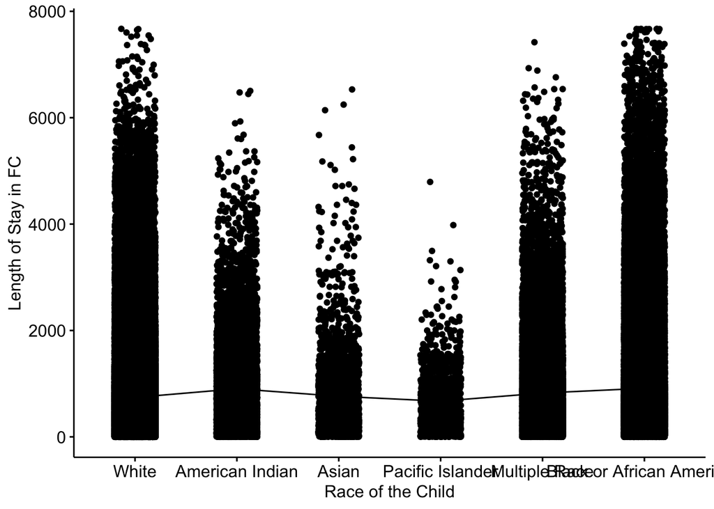

```r
#games_howell_test(foster, lifelos ~race, conf.level = 0.95)
#mean plots
ggline(foster, x = "race", y = "lifelos",
       add = c("mean_se", "jitter"),
       ylab = "Length of Stay in FC", xlab = "Race of the Child")
```

boxplot

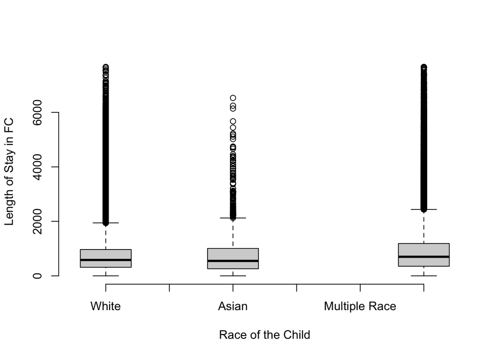

```r
boxplot(lifelos ~ race, data = foster.one.way,
        xlab = "Race of the Child", ylab = "Length of Stay in FC",
        frame = FALSE)
```

plotmeans

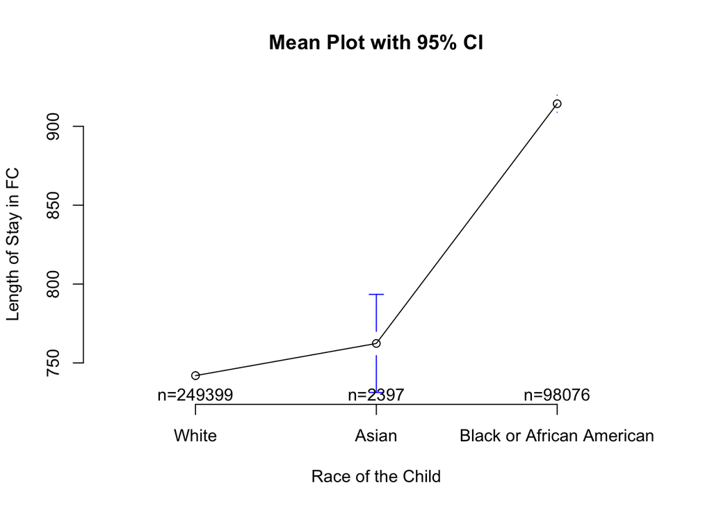

```r
plotmeans(lifelos ~ race, data=foster.one.way, frame = FALSE,
          xlab = "Race of the Child", ylab = "Length of Stay in FC",
          main = "Mean Plot with 95% CI")
```

diagnostic

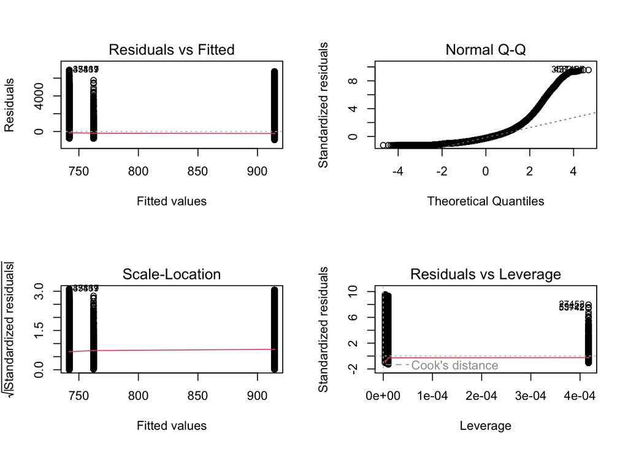

```r
par(mfrow=c(2,2))
plot(one.way1)
```

residuals vs fitted

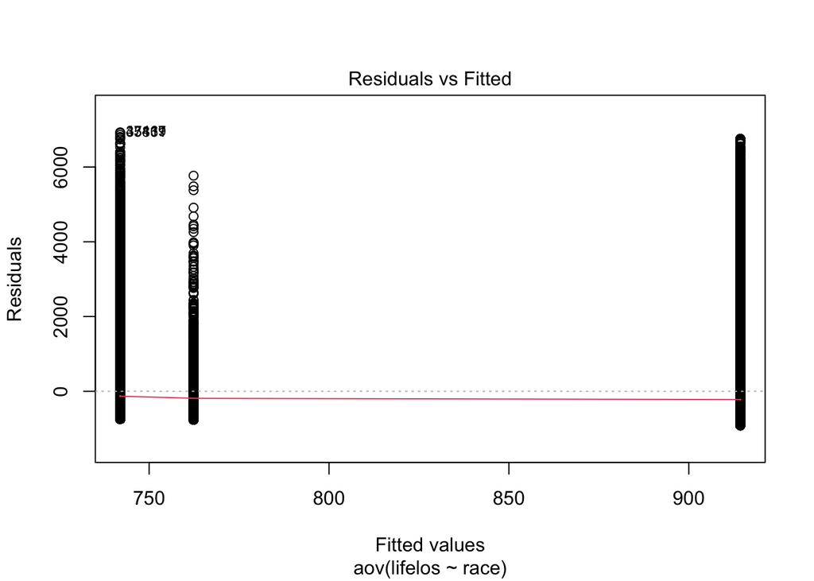

```r
plot(one.way1, 1)
```

levenes test

```r
leveneTest(lifelos ~ race, data = foster.one.way)
```

```
Levene's Test for Homogeneity of Variance (center = median)
          Df F value    Pr(>F)
group      2    1657 < 2.2e-16 ***
      349869
---
Signif. codes:  0 '***' 0.001 '**' 0.01 '*' 0.05 '.' 0.1 ' ' 1
```

normality

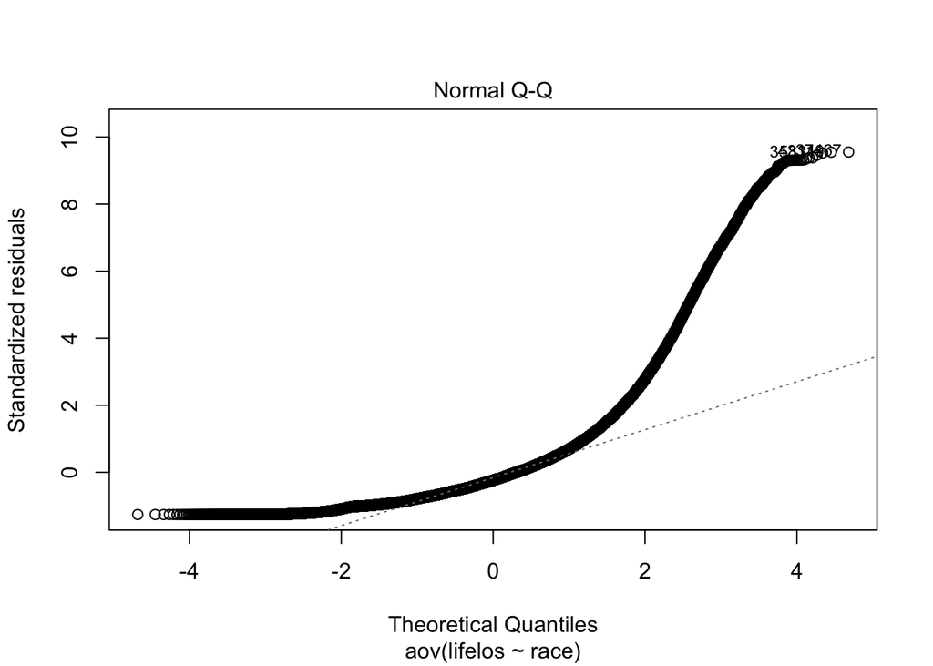

```r
plot(one.way1, 2)
```

nonparametric

```r
kruskal.test(lifelos ~ race, data = foster.one.way)
```

```
    Kruskal-Wallis rank sum test

data:  lifelos by race
Kruskal-Wallis chi-squared = 2636.7, df = 2, p-value < 2.2e-16
```

boxplot

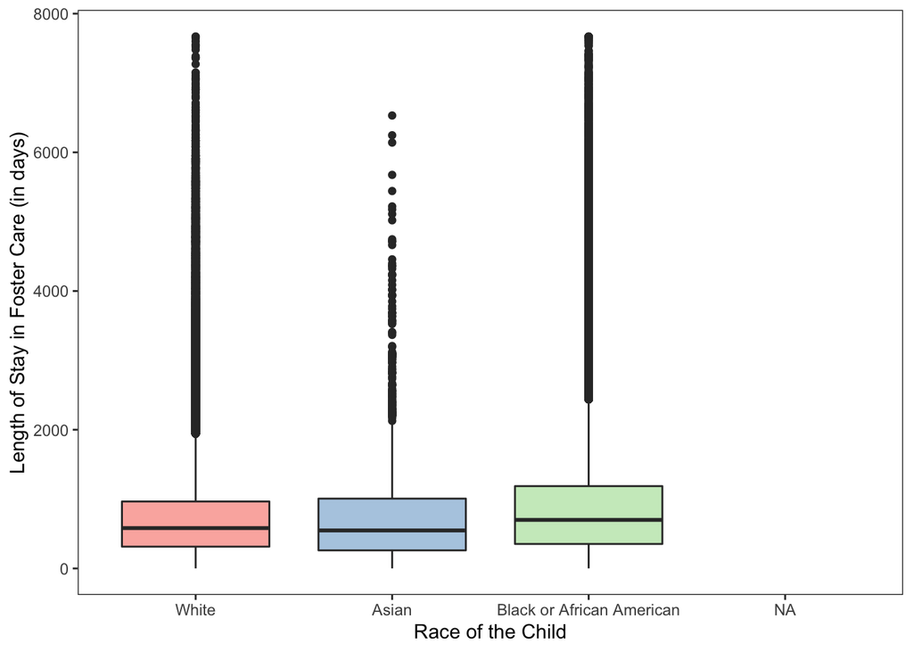

```r
ggplot(foster.one.way, aes(race, lifelos)) +
  geom_boxplot(aes(fill = race), show.legend = FALSE) +
  labs(x="Race of the Child", y="Length of Stay in Foster Care (in days)") +
  theme_bw() +
  theme(panel.grid.major = element_blank(), panel.grid.minor = element_blank()) +
  #geom_text(data = foster.one.way, aes(x = race, y = lifelos), size = 3, vjust=-1, hjust =-1) +
  scale_fill_brewer(palette = "Pastel1")
```